# NCI-60 Gene Expression Statistics

Exploratory high-dimensional biostatistics with explicit uncertainty and limitations

# 1 Purpose and statistical scope

This report consolidates the actual methods used in the NCI-60 coursework: one-way ANOVA, Benjamini-Hochberg (BH) adjustment, hierarchical clustering, K-means, PCA, bootstrap, and permutation testing. It is an exploratory analysis of a small, high-dimensional cell-line dataset, not a biomarker study or a validated cancer classifier.

# 2 Data

```r
data("NCI60", package = "ISLR2")

selected_types <- c("BREAST", "COLON", "NSCLC", "MELANOMA", "RENAL")
selected <- NCI60$labs %in% selected_types
nci_raw <- NCI60$data[selected, , drop = FALSE]
nci_labs <- factor(NCI60$labs[selected], levels = selected_types)

dim(NCI60$data)
```

```
## [1]   64 6830
```

```r
dim(nci_raw)
```

```
## [1]   40 6830
```

```r
table(nci_labs)
```

```
## nci_labs
##   BREAST    COLON    NSCLC MELANOMA    RENAL
##        7        7        9        8        9
```

The package dataset contains 64 cell lines and 6,830 expression variables. The coursework subset contains 40 cell lines from five cancer types. No raw data file is stored in this repository.

# 3 Preprocessing

Each expression variable is standardized once across the selected 40 cell lines.

```r
nci_scaled <- scale(nci_raw)
stopifnot(identical(dim(nci_scaled), c(40L, 6830L)))
```

The original third assignment included a duplicated scaling step in one path. The consolidated version removes that duplication without changing the intended analysis.

# 4 Hierarchical clustering

The coursework compared single, complete, average, and centroid linkage using Euclidean distance. Complete linkage is shown because it had relatively visible label alignment in this dataset; it is not claimed to be generally superior.

```r
linkage_methods <- c("single", "complete", "average", "centroid")
hc_list <- lapply(linkage_methods, function(method) {
  hclust(dist(nci_scaled), method = method)
})
names(hc_list) <- linkage_methods

cluster_tables <- lapply(hc_list, function(hc) {
  table(Cluster = cutree(hc, k = 5), Cancer = nci_labs)
})

cluster_tables$complete
```

```
##        Cancer
## Cluster BREAST COLON NSCLC MELANOMA RENAL
##       1      2     0     2        1     5
##       2      1     4     6        1     4
##       3      2     3     0        0     0
##       4      0     0     1        0     0
##       5      2     0     0        6     0
```

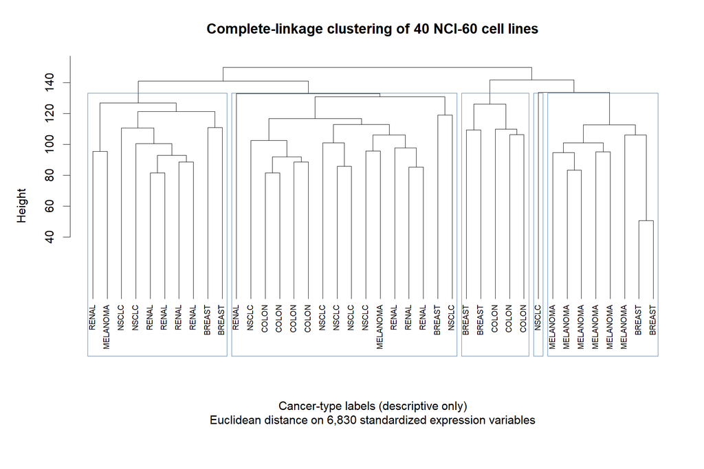

Six MELANOMA cell lines occur together in one of the five complete-linkage clusters, but the contingency table also shows substantial mixing. This is an in-sample structure description, not independent cancer-type prediction.

# 5 Gene-wise ANOVA and multiple testing

A one-way ANOVA is run for each of 6,830 variables. With thousands of simultaneous tests, raw p-values cannot by themselves define discoveries.

```r
anova_p <- apply(nci_scaled, 2, function(x) {
  anova(lm(x ~ nci_labs))$`Pr(>F)`[1]
})

gene_anova <- data.frame(
  Variable = colnames(nci_scaled),
  Raw_P = anova_p,
  BH_Adjusted_P = p.adjust(anova_p, method = "BH"),
  stringsAsFactors = FALSE
)
gene_anova <- gene_anova[order(gene_anova$Raw_P), ]

bh_counts <- c(
  total = nrow(gene_anova),
  q_0_05 = sum(gene_anova$BH_Adjusted_P < 0.05),
  q_0_10 = sum(gene_anova$BH_Adjusted_P < 0.10)
)
bh_counts
```

```
##  total q_0_05 q_0_10
##   6830   1437   2169
```

```r
head(gene_anova, 20)
```

```
##      Variable        Raw_P BH_Adjusted_P
## 282       282 9.648311e-09  3.438234e-05
## 262       262 1.006804e-08  3.438234e-05
## 4099     4099 2.220961e-08  5.056387e-05
## 2024     2024 4.925580e-08  8.410427e-05
## 4236     4236 1.466334e-07  1.851689e-04
## 5955     5955 2.031220e-07  1.851689e-04
## 5898     5898 2.050644e-07  1.851689e-04
## 233       233 2.384847e-07  1.851689e-04
## 237       237 2.440000e-07  1.851689e-04
## 2551     2551 3.001314e-07  1.882015e-04
## 5619     5619 3.177258e-07  1.882015e-04
## 5899     5899 3.473711e-07  1.882015e-04
## 4100     4100 3.582166e-07  1.882015e-04
## 4327     4327 3.902467e-07  1.903846e-04
## 4295     4295 4.593696e-07  1.934837e-04
## 4298     4298 4.631076e-07  1.934837e-04
## 5512     5512 4.815845e-07  1.934837e-04
## 321       321 5.169657e-07  1.961598e-04
## 5988     5988 6.090258e-07  2.087041e-04
## 4332     4332 6.352469e-07  2.087041e-04
```

The top 20 variables below are selected only by raw p-value rank to reproduce the coursework path. They are not labeled “significant genes.” The BH analysis is a later portfolio review check, not an analysis originally included in the third assignment.

```r
top20_variables <- gene_anova$Variable[1:20]
top20 <- nci_scaled[, top20_variables, drop = FALSE]
top20_variables
```

```
##  [1] "282"  "262"  "4099" "2024" "4236" "5955" "5898" "233"  "237"  "2551"
## [11] "5619" "5899" "4100" "4327" "4295" "4298" "5512" "321"  "5988" "4332"
```

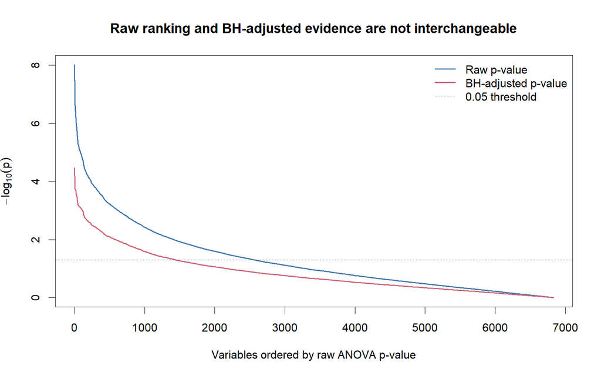

# 6 K-means on the raw-p-ranked top 20

```r
set.seed(SEED)
kmeans_top20 <- kmeans(top20, centers = 5, nstart = 50)
W <- kmeans_top20$tot.withinss

kmeans_table <- table(Cluster = kmeans_top20$cluster, Cancer = nci_labs)
kmeans_table
```

```
##        Cancer
## Cluster BREAST COLON NSCLC MELANOMA RENAL
##       1      2     0     0        7     0
##       2      1     1     1        0     0
##       3      0     6     0        0     0
##       4      3     0     7        1     0
##       5      1     0     1        0     9
```

```r
gene_influence <- do.call(rbind, lapply(seq_along(top20_variables), function(j) {
  set.seed(SEED)
  fit_j <- kmeans(top20[, -j, drop = FALSE], centers = 5, nstart = 50)
  data.frame(
    Variable = top20_variables[j],
    Abs_W_Difference = abs(W - fit_j$tot.withinss),
    stringsAsFactors = FALSE
  )
}))
gene_influence <- gene_influence[order(-gene_influence$Abs_W_Difference), ]
gene_influence
```

```
##    Variable Abs_W_Difference
## 1       282        18.204978
## 11     5619        16.935619
## 19     5988        16.868598
## 13     4100        16.442232
## 17     5512        16.302889
## 8       233        15.608414
## 9       237        14.267705
## 3      4099        13.682761
## 4      2024        13.251694
## 10     2551        13.203650
## 18      321        12.993595
## 16     4298        12.313270
## 2       262        11.554649
## 20     4332        11.225235
## 7      5898        10.890954
## 6      5955        10.261658
## 15     4295         9.362451
## 12     5899         9.298253
## 5      4236         9.294489
## 14     4327         4.095231
```

The largest leave-one-variable-out change is attached to matrix ID 282 (18.205). This is sensitivity of an in-sample clustering objective—not evidence that the ID is a clinical biomarker. The cancer labels were used to rank variables before K-means, and the same samples and labels are used to describe agreement, so the result is optimistically biased and not external validation.

# 7 PCA

```r
pca_fit <- prcomp(nci_raw, center = TRUE, scale. = TRUE)
pca20 <- pca_fit$x[, 1:20, drop = FALSE]
explained <- (pca_fit$sdev ^ 2) / sum(pca_fit$sdev ^ 2) * 100
explained[1:5]
```

```
## [1] 10.839950  9.682780  5.438843  5.161296  4.425642
```

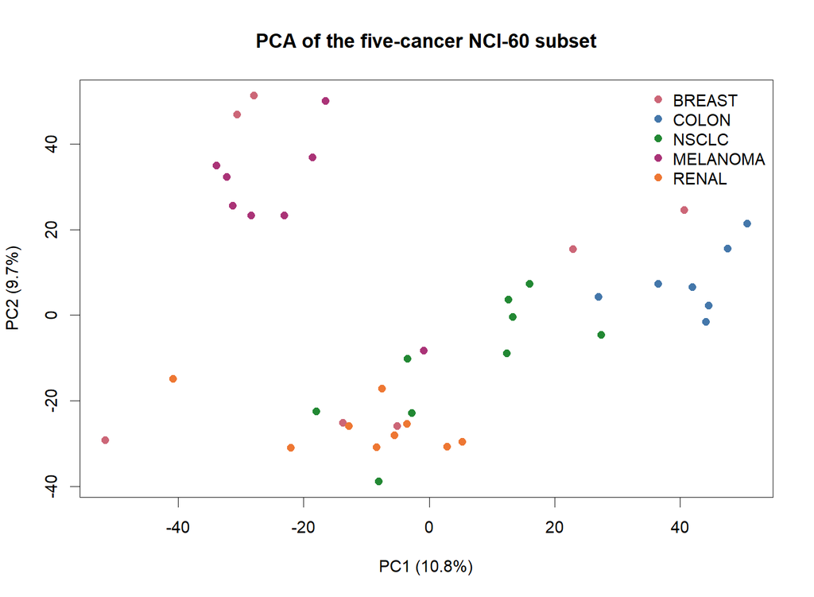

PCA is used here for unsupervised structure exploration. Separation in a score plot is not classification accuracy and does not establish a biological mechanism.

# 8 Bootstrap sensitivity for the coursework-defined leading components

The following reproduces the coursework definition: resample 40 cell-line indices with replacement, calculate the cell-line correlation matrix, and record the share of its eigenvalue sum represented by the first two components.

```r
set.seed(SEED)
boot_index <- apply(matrix(1:40, 40, 1000), 2, sample, replace = TRUE)
eigenvalues_boot <- matrix(0, nrow = 1000, ncol = 40)

for (i in 1:1000) {
  idx <- boot_index[, i]
  cor_boot <- cor(t(nci_scaled[idx, ]))
  eigenvalues_boot[i, ] <- eigen(cor_boot, symmetric = TRUE)$values
}

pc12_variance <- apply(eigenvalues_boot, 1, function(x) {
  sum(x[1:2]) / sum(x) * 100
})
bootstrap_ci <- quantile(pc12_variance, c(0.025, 0.975))
bootstrap_ci
```

```
##     2.5%    97.5%
## 22.12480 30.07429
```

This interval is a descriptive summary of sample-composition variability under the coursework definition based on the leading two eigenvalues of the resampled cell-line correlation matrix. Because the variable-wise standardization from the full selected dataset is held fixed, it is not a bootstrap confidence interval obtained by refitting the complete preprocessing and PCA pipeline in every resample.

# 9 Permutation tests for PC–label association

For each of the first 20 PC scores, a one-way ANOVA F statistic is compared with 1,000 label permutations. The +1 correction gives p-values with denominator 1,001.

```r
observed_f <- apply(pca20, 2, function(x) {
  anova(lm(x ~ nci_labs))$`F value`[1]
})

set.seed(SEED)
perm_index <- apply(matrix(1:40, 40, 1000), 2, sample, replace = FALSE)
f_perm <- matrix(NA_real_, nrow = 1000, ncol = 20)

for (i in 1:1000) {
  permuted_labs <- nci_labs[perm_index[, i]]
  f_perm[i, ] <- apply(pca20, 2, function(x) {
    anova(lm(x ~ permuted_labs))$`F value`[1]
  })
}

perm_p <- vapply(1:20, function(j) {
  (sum(f_perm[, j] >= observed_f[j]) + 1) / 1001
}, numeric(1))

permutation_results <- data.frame(
  PC = colnames(pca20),
  Permutation_P = perm_p,
  stringsAsFactors = FALSE
)
permutation_results[permutation_results$Permutation_P < 0.05, ]
```

```
##    PC Permutation_P
## 1 PC1   0.000999001
## 2 PC2   0.000999001
## 3 PC3   0.032967033
## 5 PC5   0.001998002
## 9 PC9   0.003996004
```

The threshold above is component-wise and unadjusted. Because 20 PCs are tested, a multiple-testing limitation remains; these are exploratory association checks rather than confirmatory discoveries.

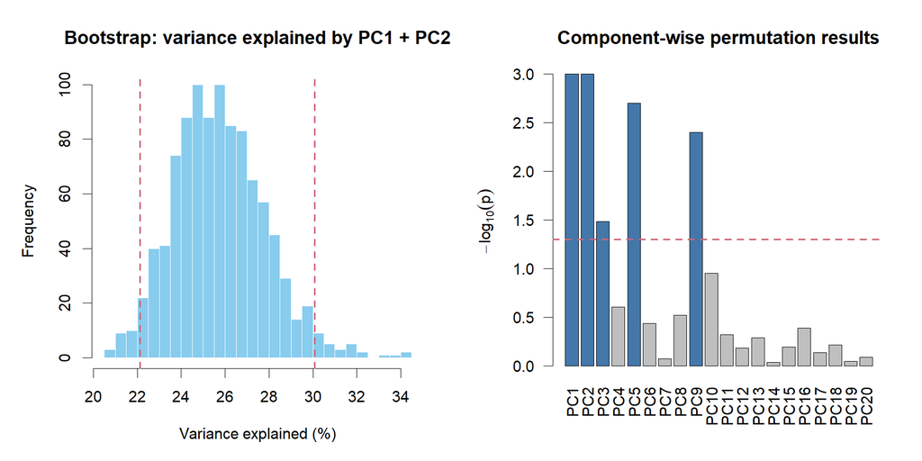

# 10 Reproducibility checks

```r
expected <- list(
  bh_q_0_05 = 1437L,
  bh_q_0_10 = 2169L,
  bootstrap_ci = c(22.12480, 30.07429),
  significant_pcs = c("PC1", "PC2", "PC3", "PC5", "PC9")
)

stopifnot(
  unname(bh_counts["q_0_05"]) == expected$bh_q_0_05,
  unname(bh_counts["q_0_10"]) == expected$bh_q_0_10,
  isTRUE(all.equal(unname(bootstrap_ci), expected$bootstrap_ci, tolerance = 1e-5)),
  identical(
    permutation_results$PC[permutation_results$Permutation_P < 0.05],
    expected$significant_pcs
  )
)

data.frame(
  Check = c("BH q < 0.05", "BH q < 0.10", "Bootstrap lower", "Bootstrap upper"),
  Value = c(bh_counts["q_0_05"], bh_counts["q_0_10"], bootstrap_ci[1], bootstrap_ci[2])
)
```

```
##                  Check      Value
## q_0_05     BH q < 0.05 1437.00000
## q_0_10     BH q < 0.10 2169.00000
## 2.5%   Bootstrap lower   22.12480
## 97.5%  Bootstrap upper   30.07429
```

# 11 Limitations

- The selected dataset has 40 cell lines and 6,830 variables.
- Cell lines are not a clinical cohort.
- Raw-p top-20 selection and clustering assessment reuse the same labeled data.
- No independent or held-out validation is performed.
- BH-adjusted results are distinct from the raw ranking and were added during portfolio review.
- Component-wise permutation tests leave multiplicity across 20 PCs unresolved.
- Matrix IDs are not interpreted as validated gene symbols or clinical biomarkers.